# MSD 2019 Final Project

A replication and extension of Ethnicity, Insurgency, and Civil War by James D. Fearon & David D. Laitin, American Political Science Review

Preston Bradham (PMB2164), Chaim Eisenbach (CE2388), Aysha Khan (ASK2256)

2019-05-13 19:54:24

# Paper Overview

Fearon and Laitin analyzed post-WWII global civil wars to see if they could create a model to predict the likelihood of civil war onset. They investigated unique characteristics of the countries at hand to see if they could hypothesize which variable played the biggest role in the making of the civil war. Such as poverty, political instability, ethnic and religious diversity.

They defined civil war as conflicts that meet three criteria: involved fighting between agents of a state and organized nonstate groups who sought to take control of a government policicies, the conflict killed at least 1,000 over its course with at least an average of 100 yearly deaths, and at least 100 were killed on both sides, including civilians attacked by rebels

Eleven hypotheses were were investigated. For example one was: “measures of country’s ethnic or religious diversity should be associated with a higher risk of civil war.” And most of the others followed suit but with different parameters in the hypothesis.

The paper concluded that there was not enough evidence to conclude that any of the hypothesis were on target and finished with saying that civil wars are incredible hard to predict, but it is easier to predict insurgencies. It includes a cast of doubt on three wide-held notions concerning political conflict findings: prevalence of civil war in the 1990s was not due to the end of the Cold War, greater religious and/or ethnic diversity, on its own does not make a country more prone to civil war, and cannot predict where a civil war will break out - based off of strong ethnic or political grievances. However, they also conclude with several policy suggestions, which are beyond the scope of this report.

# Figures

We seek to replicate the following two figures from the paper. Figure 1 plots the number of countries with ongoing civil wars by year, from 1945 to 1999 (solid line). The paper also shows the proportion of countries with at least one ongoing war in each year (dashed line). What is interesting is that this graph indicates that post-1990s civil wars were not due to the effects of the fall of the Berlin Wall (which signified the end of the Cold War). However, conflicts associated with the fall of the Soviet Union were partly responsible for the sharp increase we witness in the early 1990s.

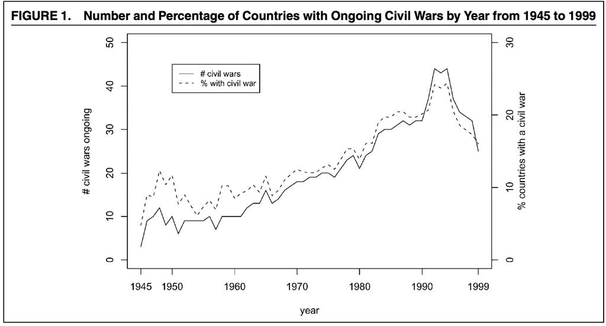

Figure 1

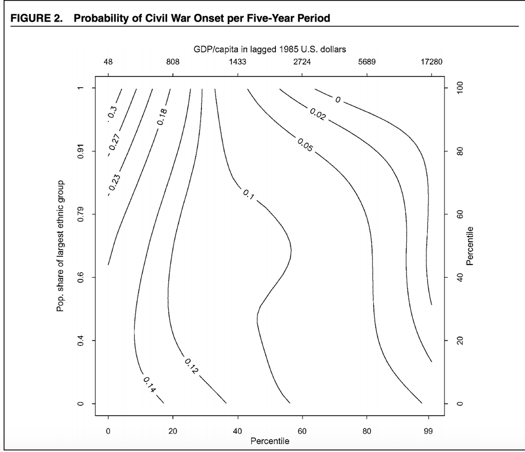

Figure 2

# Overview of Data

Their dataset uses data across the world from the period of 1945-1999 on 161 countries that had a population of at least half a million in 1990.

It includes information on the contries: economy, location, population, employment, minerals/resources, civil war information (time frame, deaths, leader, etc.), ethnic onset, oil, GDP, Colonial country, religion percentage, and more. It allows us to explore various parameteres. Originally we had used the data as is, but realized that one row had onset==4 so we got rid of it as it seemed to be an error in the data so we got rid of it.

# Conclusions

The paper concludes: “The prevalence of internal war in the 1990s is mainly the result of an accumulation of protracted conflicts since the 1950s rather than a sudden change associated with a new, post-Cold War international system.”

The authors of the paper further write that: “…the civil wars of the period have structural roots, in the combination of a simple, robust military technology and decolonization, which created an international system numerically dominated by fragile states with limited administrative control of their peripheries.” Having a poor economy with a bleak future can make joining an insurgency an appealing option for someone who feels they will not have a successful future. So an environment with a weak government that doesn’t back up a robust economic system is a good breeding ground for an insurgency. Ethnic diversity on it’s own may not necessarily preclude a civil war becuase as long as there are jobs available and the potential to succeed in life, younger people will not see joining a war as an appealing option.

### Replication of Figures 1&2

Figure 2 is a contour plot that plots the percentile of countries in civil war versus population fractions of the majority ethnic group and GDP. This plot is very difficult to understand, so we broke it down into 2 plots: one that plots percentile of countries in civil war versus GDP per capita, the other per fraction of the largest ethnicity group. For Plot 2 we can see a visible linear correlation, so a good pearsons coefficent. However, on the second it’s not as apparent. We tried to make the plots more legible/efficient but we see now why the authors used the more elaborate format.

### Replication of first column of table 1

Model 1 in Table 1 shows the results of a logit analysis. Using onset as the dependent variable. With a standard glm model we were able to recreate column 1 of table 1. Our numbers match the papers numbers. We also dropped gdp and ethfrac to see what would happen. Using all the variables the authors use for model 1 in table 1 we get the same results. When we remove gdp we see a significant change in the intercept. When we remove ethfrac the difference is negligible.

### Our conclusions for the extensions

### By Continent

[Note: South Africa here refers to the geographic South Africa, not specifically the country South Africa]

We can look at a these conflicts through an economic view. We know that after World War II the victors had an economic growth period called the postwar economic boom starting at 1950 which lasted until early 1970’s. So the countries that were involved in the postwar economic boom saw fewer civil wars during that time period. However, 1971 was the collapse of the Bretton Woods Monetary system, then in 1973 there was an oil crisis, followed by the american economic recession from 1973-1975. These events could suggest why we saw a increase in South African and North Africa/Middle East civil wars, as the vestiges of institutional colonialism was fading away and the oil crisis brought a downturn to their economy which drove them to civil wars. This is similar to the political conflicts in European states post WWI, where there was a civil war.

We believe that the rise of the South Africa civil wars in the 90’s(after the colonial revolutions) was due to mineral resources. Internal conflict was brought up due to different groups of a recently developed country fighting for minerals in order to get money.

### Modeling

We reproduced Model 1 from Table 1 - the results of a logit analysis. Using onset as the dependent variable and we got the same results as the paper. We then tested the logit model and we tested a naive bayes model to do a side by side comparison.

# Figure 1 Replication

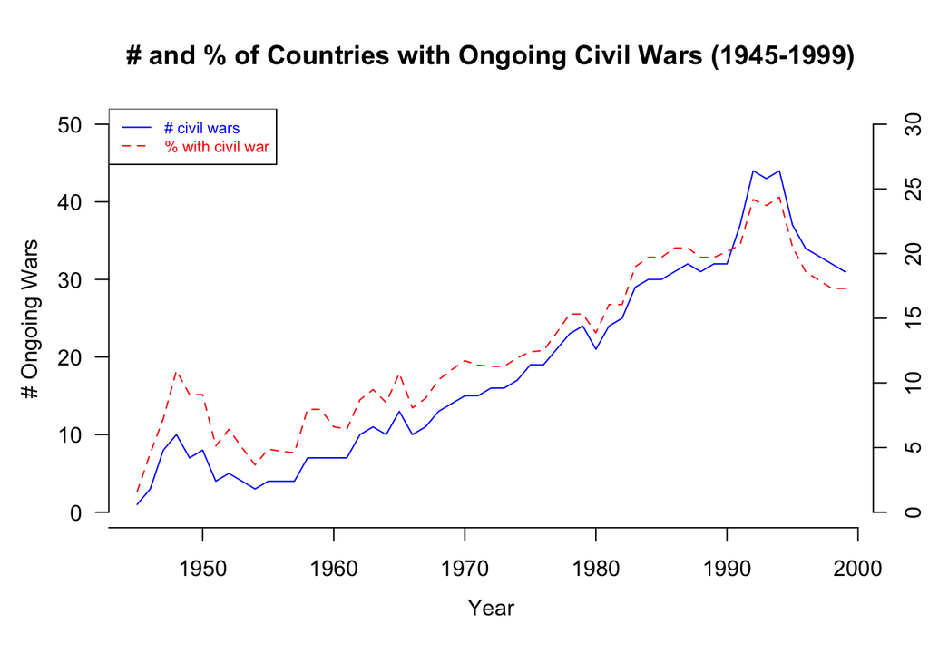

```r
repdata <- read.dta("./data/repdata.dta")
# removing onset == 4
repdata <-repdata[-2496, ]


sumwars_per_year <- repdata %>%
  group_by(year) %>%
  filter(war == 1) %>%
  summarize(
    count_wars_total = sum(wars)
  )

wars_per_year <- repdata %>%
  group_by(year) %>%
  filter(war == 1) %>%
  summarize(
    count_wars = sum(war)
  )

raw_num_countries <- repdata %>%
  group_by(year) %>%
  summarize(
    count_countries = sum(n())
  ) %>%
  ungroup(year)

perc_civil_war <- merge(wars_per_year, raw_num_countries, by = "year")
perc_civil_war <- merge(perc_civil_war, sumwars_per_year, by = "year")

perc_civil_war$perc <- (perc_civil_war$count_wars/perc_civil_war$count_countries)*100

plot(perc_civil_war$year, perc_civil_war$count_wars_total, axes = FALSE,
     ylim = c(0, 50), xlab = "", ylab = "", type = "l",
     col = "blue", main = "# and % of Countries with Ongoing Civil Wars (1945-1999)")
axis(2, ylim = c(0, 50), col = "black", las = 1)
mtext("# Ongoing Wars", side = 2, col = "black", line = 2.5)

# Plot the second plot and draw the axis on the right
par(new = TRUE)
plot(perc_civil_war$year, perc_civil_war$perc, pch = "solid", xlab = "", ylab = "", ylim = c(0, 30), axes = FALSE, type = "l", lty = 2, col = "red")
mtext("% Countries with a Civil War", side = 4, col = "black", line = 2.5)
axis(4, ylim = c(0, 30), col = "black", col.axis = "black")

# Draw the time axis
axis(1, pretty(range(perc_civil_war$year), 4))
mtext("Year", side = 1, col = "black", line = 2.5)

# Draw the legend
legend("topleft", legend = c("# civil wars", "% with civil war"),
       text.col = c("blue", "red"), col = c("blue", "red"), lty = 1:2, cex = 0.7)
```

# Figure 2 Replication: Part A

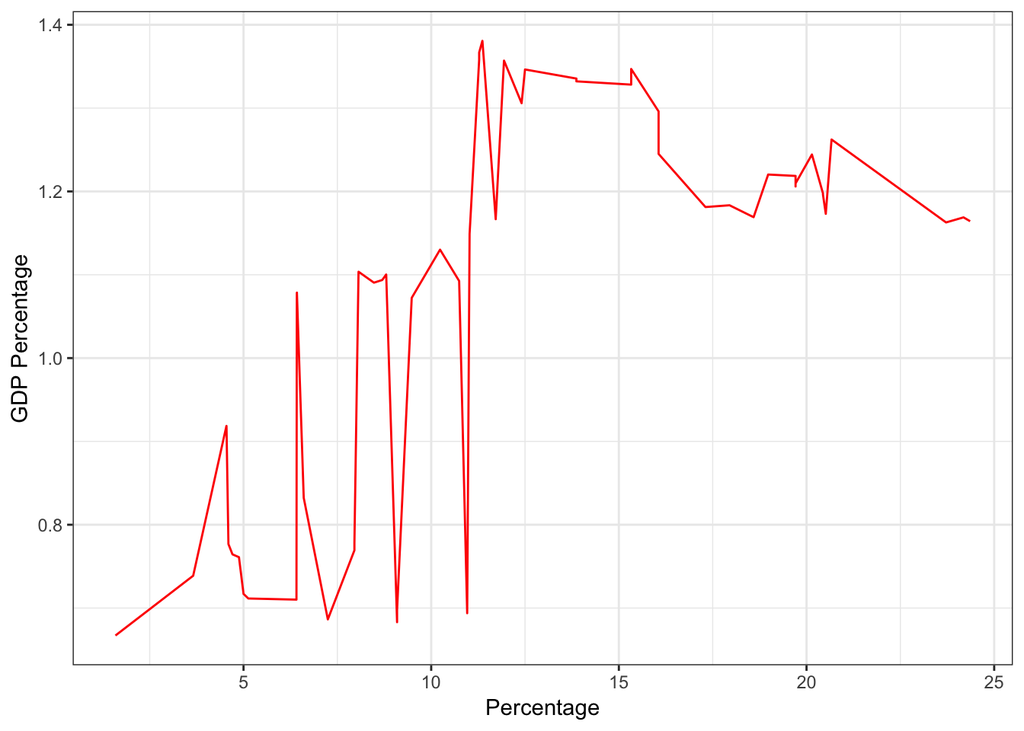

```r
gdp_per_year <- repdata %>%
  drop_na(gdpen) %>%
  drop_na(pop) %>%
  group_by(year) %>%
  summarize(
    gdp_sum = sum(gdpen),
    pop_sum = sum(pop)
  )

gdp_per_year$gdp_pc <- gdp_per_year$gdp_sum / gdp_per_year$pop_sum * 10000

gdp_per_year_perc <- merge(gdp_per_year, perc_civil_war, by = "year")
gdp_per_year_perc$cv_percentile <- round(gdp_per_year_perc$perc / max(gdp_per_year_perc$perc), digits = 4)


gdp_per_year_perc %>%
  ggplot(aes(x = perc, y = gdp_pc)) +
  geom_line(color = "red") + xlab("Percentage") + ylab("GDP Percentage")
```

# Figure 2 Replication: Part B

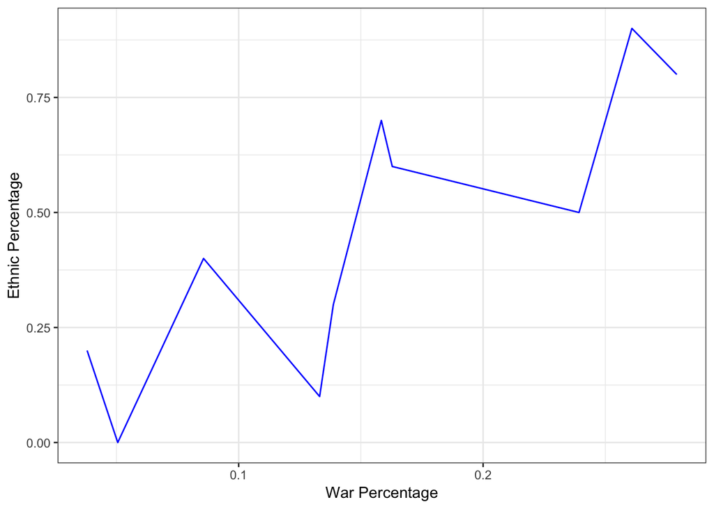

```r
rep_data_eth <- repdata %>%
  select(ethfrac, war) %>%
  mutate(ethfrac_rounded = round(ethfrac, digits = 1)) %>%
  group_by(ethfrac_rounded) %>%
  summarize(
    sum_countries = sum(n()),
    sumwars_per_eth = sum(war)
  )

rep_data_eth$war_perc = rep_data_eth$sumwars_per_eth/rep_data_eth$sum_countries


rep_data_eth %>%
  ggplot(aes(x = war_perc, y = ethfrac_rounded)) +
  geom_line(color = "blue") +xlab("War Percentage") + ylab("Ethnic Percentage")
```

# Replicating column 1 of table 1

```r
# using everything the paper does for table 1
mylogit1 <- glm(onset ~ warl + gdpenl + lpopl1 + lmtnest
+ ncontig + Oil + nwstate + instab + polity2l + ethfrac + relfrac,  data =repdata, family = "binomial")
summary(mylogit1)
```

```
##
## Call:
## glm(formula = onset ~ warl + gdpenl + lpopl1 + lmtnest + ncontig +
##     Oil + nwstate + instab + polity2l + ethfrac + relfrac, family = "binomial",
##     data = repdata)
##
## Deviance Residuals:
##     Min       1Q   Median       3Q      Max
## -1.1298  -0.1998  -0.1446  -0.1009   3.4131
##
## Coefficients:
##             Estimate Std. Error z value Pr(>|z|)
## (Intercept) -6.66554    0.73917  -9.018  < 2e-16 ***
## warl        -0.92448    0.31432  -2.941 0.003270 **
## gdpenl      -0.34659    0.07244  -4.785 1.71e-06 ***
## lpopl1       0.25650    0.07314   3.507 0.000453 ***
## lmtnest      0.22054    0.08488   2.598 0.009367 **
## ncontig      0.39191    0.27733   1.413 0.157615
## Oil          0.88587    0.27942   3.170 0.001522 **
## nwstate      1.71739    0.33858   5.072 3.93e-07 ***
## instab       0.62541    0.23554   2.655 0.007926 **
## polity2l     0.02353    0.01681   1.400 0.161656
## ethfrac      0.14435    0.37490   0.385 0.700211
## relfrac      0.28516    0.51072   0.558 0.576606
## ---
## Signif. codes:  0 '***' 0.001 '**' 0.01 '*' 0.05 '.' 0.1 ' ' 1
##
## (Dispersion parameter for binomial family taken to be 1)
##
##     Null deviance: 1068.92  on 6325  degrees of freedom
## Residual deviance:  954.44  on 6314  degrees of freedom
##   (283 observations deleted due to missingness)
## AIC: 978.44
##
## Number of Fisher Scoring iterations: 8
```

```r
# removing gdp
mylogit2<- glm(onset ~ warl  + lpopl1 + lmtnest
+ ncontig + Oil + nwstate + instab + polity2l + ethfrac + relfrac,  data =repdata, family = "binomial")
summary(mylogit2)
```

```
##
## Call:
## glm(formula = onset ~ warl + lpopl1 + lmtnest + ncontig + Oil +
##     nwstate + instab + polity2l + ethfrac + relfrac, family = "binomial",
##     data = repdata)
##
## Deviance Residuals:
##     Min       1Q   Median       3Q      Max
## -0.8056  -0.1923  -0.1486  -0.1162   3.3210
##
## Coefficients:
##             Estimate Std. Error z value Pr(>|z|)
## (Intercept) -7.61377    0.72549 -10.495  < 2e-16 ***
## warl        -0.65890    0.30503  -2.160  0.03076 *
## lpopl1       0.22018    0.07590   2.901  0.00372 **
## lmtnest      0.26488    0.08316   3.185  0.00145 **
## ncontig      0.27558    0.27149   1.015  0.31008
## Oil          0.46551    0.26050   1.787  0.07393 .
## nwstate      2.14401    0.31204   6.871 6.38e-12 ***
## instab       0.91537    0.22980   3.983 6.79e-05 ***
## polity2l    -0.01855    0.01527  -1.215  0.22444
## ethfrac      0.86025    0.37592   2.288  0.02211 *
## relfrac      0.22680    0.49024   0.463  0.64363
## ---
## Signif. codes:  0 '***' 0.001 '**' 0.01 '*' 0.05 '.' 0.1 ' ' 1
##
## (Dispersion parameter for binomial family taken to be 1)
##
##     Null deviance: 1108.2  on 6524  degrees of freedom
## Residual deviance: 1023.1  on 6514  degrees of freedom
##   (84 observations deleted due to missingness)
## AIC: 1045.1
##
## Number of Fisher Scoring iterations: 7
```

```r
# removing ethfrac
mylogit3 <- glm(onset ~ warl  + gdpenl + lpopl1 + lmtnest
+ ncontig + Oil + nwstate + instab + polity2l +  relfrac,  data =repdata, family = "binomial")
summary(mylogit3)
```

```
##
## Call:
## glm(formula = onset ~ warl + gdpenl + lpopl1 + lmtnest + ncontig +
##     Oil + nwstate + instab + polity2l + relfrac, family = "binomial",
##     data = repdata)
##
## Deviance Residuals:
##     Min       1Q   Median       3Q      Max
## -1.1252  -0.1994  -0.1448  -0.1008   3.4184
##
## Coefficients:
##             Estimate Std. Error z value Pr(>|z|)
## (Intercept) -6.63112    0.73057  -9.077  < 2e-16 ***
## warl        -0.91248    0.31239  -2.921 0.003490 **
## gdpenl      -0.35349    0.07052  -5.012 5.38e-07 ***
## lpopl1       0.25951    0.07217   3.596 0.000323 ***
## lmtnest      0.21710    0.08441   2.572 0.010116 *
## ncontig      0.39448    0.27634   1.428 0.153426
## Oil          0.90797    0.27349   3.320 0.000900 ***
## nwstate      1.72288    0.33833   5.092 3.54e-07 ***
## instab       0.62620    0.23549   2.659 0.007833 **
## polity2l     0.02372    0.01680   1.412 0.157902
## relfrac      0.33385    0.49474   0.675 0.499802
## ---
## Signif. codes:  0 '***' 0.001 '**' 0.01 '*' 0.05 '.' 0.1 ' ' 1
##
## (Dispersion parameter for binomial family taken to be 1)
##
##     Null deviance: 1068.92  on 6325  degrees of freedom
## Residual deviance:  954.58  on 6315  degrees of freedom
##   (283 observations deleted due to missingness)
## AIC: 976.58
##
## Number of Fisher Scoring iterations: 8
```

Using all the variables the authors use for model 1 in table 1 we get the same results. When we remove gdp we see a significant change in the intercept. When we remove ethfrac the difference is negligible.

```r
# using everything the paper does for table 1
# resource https://uw-csss-564.github.io/assignment-2017-4//
#mylogit1_stan <- stan_glm(onset ~ warl + gdpenl + lpopl1 + lmtnest
#+ ncontig + Oil + nwstate + instab + polity2l + ethfrac + relfrac,  data =repdata, family = "binomial")
#summary(mylogit1)
# removing gdp
#mylogit2_stan<- stan_glm(onset ~ warl  + lpopl1 + lmtnest
#+ ncontig + Oil + nwstate + instab + polity2l + ethfrac + relfrac,  data =repdata, family = "binomial")
#summary(mylogit2)

# Leave-One-Out (LOO) cross-validation, which is implemented by the loo function in the loo package

#loo_mod1 <- loo(mylogit1_stan)
#loo_mod2 <- loo(mylogit2_stan)
#compare(loo_mod1,loo_mod2)
```

### Validation on the logit model 1

```r
#data(repdata)
Train <- createDataPartition(repdata$onset, p=0.6, list=FALSE)
training <- repdata[ Train, ]
testing <- repdata[ -Train, ]

mylogit1_train <- glm(onset ~ warl  + lpopl1 + lmtnest
+ ncontig + Oil + nwstate + instab + polity2l + ethfrac + relfrac,  data = training,family = "binomial")
mylogit1_train_pred  <- predict(mylogit1_train, data=training,type="response")

#head(mylogit1_train_pred)
mylogit1_test_pred <- predict(mylogit1_train, data=testing,type="response",na.action = na.pass)
#head(mylogit1_test_pred)
log_odds_train <- predict(mylogit1_train, training)
log_odds_test <- predict(mylogit1_train, testing)

head(log_odds_test)
```

```
##         1         2         3         5         6         7
## -3.516364 -3.516364 -3.514893 -3.509813 -3.505909 -3.499765
```

```r
head(log_odds_train)
```

```
##         4         8        10        11        12        13
## -3.513718 -3.495945 -3.488475 -3.484849 -3.481282 -3.477486
```

Just experimenting with cutoff. I wasn’t able to find anything that would make me want to change the cutoff.

```r
#test_onset <- as.vector(testing$onset)
#log_odds_conf <- as.vector(log_odds)
#conf_table <- table(log_odds,testing$onset)
```

# Extensions

### Civil war by region

We wanted to see each country that had a civil war in each continent and then the time frame for it.

[figure not shown]

```r
#First five lines filter the oringal data (repdata) and such that we create the total number of civil wars,
#then the number of wars per year
# then just the number of countries,
#from this we can create the perc_civil_war where it is the same as figure2




sumwars_per_year <- repdata %>%
  group_by(year) %>%
  filter(war == 1) %>%
  summarize(
    count_wars_total = sum(wars)
  )

wars_per_year <- repdata %>%
  group_by(year) %>%
  filter(war == 1) %>%
  summarize(
    count_wars = sum(war)
  )

raw_num_countries <- repdata %>%
  group_by(year) %>%
  summarize(
    count_countries = sum(n())
  ) %>%
  ungroup(year)

perc_civil_war <- merge(wars_per_year, raw_num_countries, by = "year")
perc_civil_war <- merge(perc_civil_war, sumwars_per_year, by = "year")

#We then want to filter the original by region: South America, Western, East Europe,
#South Africa, Asia, and North Africa/Middle East
#Then take the total of civil wars per for each region
# then normalize them as percents by dividing each by the perc_civil_war from above


#South America
southamerica <- repdata  %>% filter (lamerica == 1)
wars_per_year_SA <- southamerica %>% group_by( year) %>% summarize(count_wars = sum(war))
percent_SA <- (wars_per_year_SA$count_wars/perc_civil_war$count_wars)

#Western
western <- repdata %>% filter (western == 1)
wars_per_year_WS <- western %>% group_by(year)  %>% summarize(count_wars = sum(war))
percent_WS <- (wars_per_year_WS$count_wars/perc_civil_war$count_wars)

#East Europe
easteurope <- repdata  %>% filter (eeurop == 1)
wars_per_year_EE <- easteurope %>% group_by(year)  %>% summarize(count_wars = sum(war))
percent_EE <- (wars_per_year_SA$count_wars/perc_civil_war$count_wars)

#South Africa
southafrica <- repdata  %>% filter (ssafrica == 1)
wars_per_year_SAF <- southafrica%>% group_by(year)  %>% summarize(count_wars = sum(war))
percent_SAF <- (wars_per_year_SAF$count_wars/perc_civil_war$count_wars)

#Asia
asia <- repdata  %>% filter (asia == 1)
wars_per_year_AS <- asia %>% group_by(year) %>% summarize(count_wars = sum(war))
percent_AS <- (wars_per_year_AS$count_wars/perc_civil_war$count_wars)

#North African and Middle East
northafricamiddleeast <- repdata %>% filter (nafrme == 1)
wars_per_year_NAM <- northafricamiddleeast %>% group_by(year) %>% summarize(count_wars = sum(war))
percent_NAM <- (wars_per_year_NAM$count_wars/perc_civil_war$count_wars)


#Plot each continent percent civil war on same plot to show differences
plot(wars_per_year_SA$year, percent_SA, axes = FALSE,
     ylim = c(0, 1), xlim = c(1945, 2000), xlab = "" , ylab = "", type = "l",
     col = "purple", main = "% of Civil Wars by Continent (1945-1999)")
lines(wars_per_year_WS$year, percent_WS, col = "green")
lines(wars_per_year_EE$year, percent_EE, col = "coral")
lines(wars_per_year_SAF$year, percent_SAF, col = "blue")
lines(wars_per_year_AS$year, percent_AS, col = "red")
lines(wars_per_year_NAM$year, percent_NAM, col = "black")

#Label plot x/y axis
axis(2, ylim = c(0, 1), col = "black", las = 1)
axis(1, xlim = c(1945, 1999), col = "black", las = 1)
mtext("Percent ", side = 2, col = "black", line = 2.5)
mtext("Year", side = 1, col = "black", line = 2.5)

#Give a legend to plot for each continent
legend("topright", legend = c("South America", "North America & Western Europe", "Eastern Europe","South Africa", "Asia", "North Africa & Middle East" ), text.col = c("purple", "green", "coral", "blue", "red", "black"), col = c("purple", "green", "coral", "blue", "red", "black"), lty = 1:2, cex = 0.5)
```

```r
#We wanted to see each country that had a civil war in each continent and then the time frame for it

#we filtered by country and year looking countries that had civil wars
#ordered it by year, then use ave/paste0  to find the time frame of each civil
#then took away duplicates
#Its important to note that if a country had multiple civil wars over various time frames, we took the date of the first
#and the end date of the last for the time frames. This is because there was still internal disruptionduring the "off" years
#Which is why Russia is shown as 1946-1999, becasue they had their internal disputes early on 1946-1950, then was a part of the Cold War,
#up until the contry fell of which the 1992-1999 civil wars started

#South America
wars_country_year_SA <- southamerica %>% group_by(country,year) %>% filter(war==1 )%>% summarize(Year = year)
wars_country_year_SA <- wars_country_year_SA [order(wars_country_year_SA$Year),]
wars_country_year_SA$min = ave(wars_country_year_SA$Year, wars_country_year_SA$country, FUN = min)
wars_country_year_SA$max = ave(wars_country_year_SA$Year, wars_country_year_SA$country, FUN = max)
wars_country_year_SA$range = paste0(wars_country_year_SA$min, " - ", wars_country_year_SA$max)
wars_country_year_SA = wars_country_year_SA[!duplicated(wars_country_year_SA$country),]
wars_country_year_SA <- wars_country_year_SA[,c(1,6)]
names(wars_country_year_SA) <- c("South America", "Conflict Time Frame")


#Western Countries
wars_country_year_W <- western %>% group_by(country,year) %>% filter(war==1 )%>% summarize(Year = year)
wars_country_year_W <- wars_country_year_W [order(wars_country_year_W$Year),]
wars_country_year_W$min = ave(wars_country_year_W$Year, wars_country_year_W$country, FUN = min)
wars_country_year_W$max = ave(wars_country_year_W$Year, wars_country_year_W$country, FUN = max)
wars_country_year_W$range = paste0(wars_country_year_W$min, " - ", wars_country_year_W$max)
wars_country_year_W = wars_country_year_W[!duplicated(wars_country_year_W$country),]
wars_country_year_W <- wars_country_year_W[,c(1,6)]
names(wars_country_year_W) <- c("Western Countries", "Conflict Time Frame")


#East Europe
wars_country_year_EE <- easteurope %>% group_by(country,year) %>% filter(war==1 )%>% summarize(Year = year)
wars_country_year_EE <- wars_country_year_EE [order(wars_country_year_EE$Year),]
wars_country_year_EE$min = ave(wars_country_year_EE$Year, wars_country_year_EE$country, FUN = min)
wars_country_year_EE$max = ave(wars_country_year_EE$Year, wars_country_year_EE$country, FUN = max)
wars_country_year_EE$range = paste0(wars_country_year_EE$min, " - ", wars_country_year_EE$max)
wars_country_year_EE = wars_country_year_EE[!duplicated(wars_country_year_EE$country),]
wars_country_year_EE <- wars_country_year_EE[,c(1,6)]
names(wars_country_year_EE) <- c("East Europe", "Conflict Time Frame")


#South Africa
wars_country_year_SAF <- southafrica %>% group_by(country,year) %>% filter(war==1 )%>% summarize(Year = year)
wars_country_year_SAF <- wars_country_year_SAF [order(wars_country_year_SAF$Year),]
wars_country_year_SAF$min = ave(wars_country_year_SAF$Year, wars_country_year_SAF$country, FUN = min)
wars_country_year_SAF$max = ave(wars_country_year_SAF$Year, wars_country_year_SAF$country, FUN = max)
wars_country_year_SAF$range = paste0(wars_country_year_SAF$min, " - ", wars_country_year_SAF$max)
wars_country_year_SAF = wars_country_year_SAF[!duplicated(wars_country_year_SAF$country),]
wars_country_year_SAF <- wars_country_year_SAF[,c(1,6)]
names(wars_country_year_SAF) <- c("South Africa", "Conflict Time Frame")


#Asia
wars_country_year_A <- asia %>% group_by(country,year) %>% filter(war==1 )%>% summarize(Year = year)
wars_country_year_A <- wars_country_year_A [order(wars_country_year_A$Year),]
wars_country_year_A$min = ave(wars_country_year_A$Year, wars_country_year_A$country, FUN = min)
wars_country_year_A$max = ave(wars_country_year_A$Year, wars_country_year_A$country, FUN = max)
wars_country_year_A$range = paste0(wars_country_year_A$min, " - ", wars_country_year_A$max)
wars_country_year_A = wars_country_year_A[!duplicated(wars_country_year_A$country),]
wars_country_year_A <- wars_country_year_A[,c(1,6)]
names(wars_country_year_A) <- c("Asia", "Conflict Time Frame")


#North Africa and Middle East
wars_country_year_NA <- northafricamiddleeast %>% group_by(country,year) %>% filter(war==1 )%>% summarize(Year = year)
wars_country_year_NA <- wars_country_year_NA [order(wars_country_year_NA$Year),]
wars_country_year_NA$min = ave(wars_country_year_NA$Year, wars_country_year_NA$country, FUN = min)
wars_country_year_NA$max = ave(wars_country_year_NA$Year, wars_country_year_NA$country, FUN = max)
wars_country_year_NA$range = paste0(wars_country_year_NA$min, " - ", wars_country_year_NA$max)
wars_country_year_NA = wars_country_year_NA[!duplicated(wars_country_year_NA$country),]
wars_country_year_NA <- wars_country_year_NA[,c(1,6)]
names(wars_country_year_NA) <- c("North Africa and Middle East", "Conflict Time Frame")



#Prints all tables for the Region

table(wars_country_year_SA)
```

```
##                 Conflict Time Frame
## South America    1947 - 1947 1948 - 1948 1948 - 1999 1952 - 1952
##   ARGENTINA                0           0           0           0
##   BOLIVIA                  0           0           0           1
##   COLOMBIA                 0           0           1           0
##   COSTARICA                0           1           0           0
##   CUBA                     0           0           0           0
##   DOMINICAN REP.           0           0           0           0
##   EL SALVADOR              0           0           0           0
##   GUATEMALA                0           0           0           0
##   HAITI                    0           0           0           0
##   NICARAGUA                0           0           0           0
##   PARAGUAY                 1           0           0           0
##   PERU                     0           0           0           0
##                 Conflict Time Frame
## South America    1955 - 1977 1958 - 1959 1965 - 1965 1968 - 1996
##   ARGENTINA                1           0           0           0
##   BOLIVIA                  0           0           0           0
##   COLOMBIA                 0           0           0           0
##   COSTARICA                0           0           0           0
##   CUBA                     0           1           0           0
##   DOMINICAN REP.           0           0           1           0
##   EL SALVADOR              0           0           0           0
##   GUATEMALA                0           0           0           1
##   HAITI                    0           0           0           0
##   NICARAGUA                0           0           0           0
##   PARAGUAY                 0           0           0           0
##   PERU                     0           0           0           0
##                 Conflict Time Frame
## South America    1978 - 1988 1979 - 1992 1981 - 1995 1991 - 1995
##   ARGENTINA                0           0           0           0
##   BOLIVIA                  0           0           0           0
##   COLOMBIA                 0           0           0           0
##   COSTARICA                0           0           0           0
##   CUBA                     0           0           0           0
##   DOMINICAN REP.           0           0           0           0
##   EL SALVADOR              0           1           0           0
##   GUATEMALA                0           0           0           0
##   HAITI                    0           0           0           1
##   NICARAGUA                1           0           0           0
##   PARAGUAY                 0           0           0           0
##   PERU                     0           0           1           0
```

```r
table(wars_country_year_W)
```

```
##                  Conflict Time Frame
## Western Countries 1945 - 1949 1969 - 1999
##            GREECE           1           0
##            UK               0           1
```

```r
table(wars_country_year_EE)
```

```
##             Conflict Time Frame
## East Europe  1947 - 1999 1991 - 1991 1992 - 1992 1992 - 1994 1992 - 1995
##   AZERBAIJAN           0           0           0           1           0
##   BOSNIA               0           0           0           0           1
##   CROATIA              0           0           0           0           1
##   GEORGIA              0           0           0           1           0
##   MOLDOVA              0           0           1           0           0
##   RUSSIA               1           0           0           0           0
##   TAJIKISTAN           0           0           0           0           0
##   YUGOSLAVIA           0           1           0           0           0
##             Conflict Time Frame
## East Europe  1992 - 1997
##   AZERBAIJAN           0
##   BOSNIA               0
##   CROATIA              0
##   GEORGIA              0
##   MOLDOVA              0
##   RUSSIA               0
##   TAJIKISTAN           1
##   YUGOSLAVIA           0
```

```r
table(wars_country_year_NA)
```

```
##                             Conflict Time Frame
## North Africa and Middle East 1948 - 1969 1958 - 1990 1959 - 1974
##             ALGERIA                    0           0           0
##             CYPRUS                     0           0           0
##             IRAN                       0           0           0
##             IRAQ                       0           0           1
##             JORDAN                     0           0           0
##             LEBANON                    0           1           0
##             MOROCCO                    0           0           0
##             TURKEY                     0           0           0
##             YEMEN                      0           0           0
##             YEMEN ARAB REP.            1           0           0
##             YEMEN PEOP. REP.           0           0           0
##                             Conflict Time Frame
## North Africa and Middle East 1962 - 1999 1970 - 1970 1974 - 1974
##             ALGERIA                    1           0           0
##             CYPRUS                     0           0           1
##             IRAN                       0           0           0
##             IRAQ                       0           0           0
##             JORDAN                     0           1           0
##             LEBANON                    0           0           0
##             MOROCCO                    0           0           0
##             TURKEY                     0           0           0
##             YEMEN                      0           0           0
##             YEMEN ARAB REP.            0           0           0
##             YEMEN PEOP. REP.           0           0           0
##                             Conflict Time Frame
## North Africa and Middle East 1975 - 1988 1977 - 1999 1978 - 1993
##             ALGERIA                    0           0           0
##             CYPRUS                     0           0           0
##             IRAN                       0           0           1
##             IRAQ                       0           0           0
##             JORDAN                     0           0           0
##             LEBANON                    0           0           0
##             MOROCCO                    1           0           0
##             TURKEY                     0           1           0
##             YEMEN                      0           0           0
##             YEMEN ARAB REP.            0           0           0
##             YEMEN PEOP. REP.           0           0           0
##                             Conflict Time Frame
## North Africa and Middle East 1986 - 1987 1994 - 1994
##             ALGERIA                    0           0
##             CYPRUS                     0           0
##             IRAN                       0           0
##             IRAQ                       0           0
##             JORDAN                     0           0
##             LEBANON                    0           0
##             MOROCCO                    0           0
##             TURKEY                     0           0
##             YEMEN                      0           1
##             YEMEN ARAB REP.            0           0
##             YEMEN PEOP. REP.           1           0
```

```r
table (wars_country_year_SAF)
```

```
##                       Conflict Time Frame
## South Africa           1960 - 1999 1962 - 1999 1963 - 1999 1965 - 1999
##   ANGOLA                         0           0           0           0
##   BURUNDI                        0           0           0           0
##   CENTRAL AFRICAN REP.           0           0           0           0
##   CHAD                           0           0           0           1
##   CONGO                          0           0           0           0
##   DEM. REP. CONGO                1           0           0           0
##   DJIBOUTI                       0           0           0           0
##   ETHIOPIA                       0           0           0           0
##   GUINEA BISSAU                  0           0           0           0
##   LIBERIA                        0           0           0           0
##   MALI                           0           0           0           0
##   MOZAMBIQUE                     0           0           0           0
##   NIGERIA                        0           0           0           0
##   RWANDA                         0           1           0           0
##   SENEGAL                        0           0           0           0
##   SIERRA LEONE                   0           0           0           0
##   SOMALIA                        0           0           0           0
##   SOUTH AFRICA                   0           0           0           0
##   SUDAN                          0           0           1           0
##   UGANDA                         0           0           0           0
##   ZIMBABWE                       0           0           0           0
##                       Conflict Time Frame
## South Africa           1967 - 1970 1972 - 1987 1972 - 1999 1974 - 1999
##   ANGOLA                         0           0           0           0
##   BURUNDI                        0           0           1           0
##   CENTRAL AFRICAN REP.           0           0           0           0
##   CHAD                           0           0           0           0
##   CONGO                          0           0           0           0
##   DEM. REP. CONGO                0           0           0           0
##   DJIBOUTI                       0           0           0           0
##   ETHIOPIA                       0           0           0           1
##   GUINEA BISSAU                  0           0           0           0
##   LIBERIA                        0           0           0           0
##   MALI                           0           0           0           0
##   MOZAMBIQUE                     0           0           0           0
##   NIGERIA                        1           0           0           0
##   RWANDA                         0           0           0           0
##   SENEGAL                        0           0           0           0
```

[output cut: 60 more lines]

```
##   DJIBOUTI                       1           0           0
##   ETHIOPIA                       0           0           0
##   GUINEA BISSAU                  0           0           1
##   LIBERIA                        0           0           0
##   MALI                           0           0           0
##   MOZAMBIQUE                     0           0           0
##   NIGERIA                        0           0           0
##   RWANDA                         0           0           0
##   SENEGAL                        0           0           0
##   SIERRA LEONE                   0           0           0
##   SOMALIA                        0           0           0
##   SOUTH AFRICA                   0           0           0
##   SUDAN                          0           0           0
##   UGANDA                         0           0           0
##   ZIMBABWE                       0           0           0
```

```r
table (wars_country_year_A)
```

```
##              Conflict Time Frame
## Asia          1946 - 1999 1948 - 1999 1949 - 1950 1950 - 1999 1952 - 1999
##   AFGHANISTAN           0           0           0           0           0
##   BANGLADESH            0           0           0           0           0
##   BURMA                 0           1           0           0           0
##   CAMBODIA              0           0           0           0           0
##   CHINA                 1           0           0           0           0
##   INDIA                 0           0           0           0           1
##   INDONESIA             0           0           0           1           0
##   KOREA, S.             0           0           1           0           0
##   LAOS                  0           0           0           0           0
##   NEPAL                 0           0           0           0           0
##   PAKISTAN              0           0           0           0           0
##   PAPUA N.G.            0           0           0           0           0
##   PHILIPPINES           1           0           0           0           0
##   SRI LANKA             0           0           0           0           0
##   VIETNAM, S.           0           0           0           0           0
##              Conflict Time Frame
## Asia          1960 - 1973 1960 - 1975 1970 - 1992 1971 - 1999 1976 - 1997
##   AFGHANISTAN           0           0           0           0           0
##   BANGLADESH            0           0           0           0           1
##   BURMA                 0           0           0           0           0
##   CAMBODIA              0           0           1           0           0
##   CHINA                 0           0           0           0           0
##   INDIA                 0           0           0           0           0
##   INDONESIA             0           0           0           0           0
##   KOREA, S.             0           0           0           0           0
##   LAOS                  1           0           0           0           0
##   NEPAL                 0           0           0           0           0
##   PAKISTAN              0           0           0           1           0
##   PAPUA N.G.            0           0           0           0           0
##   PHILIPPINES           0           0           0           0           0
##   SRI LANKA             0           0           0           1           0
##   VIETNAM, S.           0           1           0           0           0
##              Conflict Time Frame
## Asia          1978 - 1999 1988 - 1998 1997 - 1999
##   AFGHANISTAN           1           0           0
##   BANGLADESH            0           0           0
##   BURMA                 0           0           0
##   CAMBODIA              0           0           0
##   CHINA                 0           0           0
##   INDIA                 0           0           0
##   INDONESIA             0           0           0
##   KOREA, S.             0           0           0
##   LAOS                  0           0           0
##   NEPAL                 0           0           1
##   PAKISTAN              0           0           0
##   PAPUA N.G.            0           1           0
##   PHILIPPINES           0           0           0
##   SRI LANKA             0           0           0
##   VIETNAM, S.           0           0           0
```

```r
table (wars_country_year_NA)
```

```
##                             Conflict Time Frame
## North Africa and Middle East 1948 - 1969 1958 - 1990 1959 - 1974
##             ALGERIA                    0           0           0
##             CYPRUS                     0           0           0
##             IRAN                       0           0           0
##             IRAQ                       0           0           1
##             JORDAN                     0           0           0
##             LEBANON                    0           1           0
##             MOROCCO                    0           0           0
##             TURKEY                     0           0           0
##             YEMEN                      0           0           0
##             YEMEN ARAB REP.            1           0           0
##             YEMEN PEOP. REP.           0           0           0
##                             Conflict Time Frame
## North Africa and Middle East 1962 - 1999 1970 - 1970 1974 - 1974
##             ALGERIA                    1           0           0
##             CYPRUS                     0           0           1
##             IRAN                       0           0           0
##             IRAQ                       0           0           0
##             JORDAN                     0           1           0
##             LEBANON                    0           0           0
##             MOROCCO                    0           0           0
##             TURKEY                     0           0           0
##             YEMEN                      0           0           0
##             YEMEN ARAB REP.            0           0           0
##             YEMEN PEOP. REP.           0           0           0
##                             Conflict Time Frame
## North Africa and Middle East 1975 - 1988 1977 - 1999 1978 - 1993
##             ALGERIA                    0           0           0
##             CYPRUS                     0           0           0
##             IRAN                       0           0           1
##             IRAQ                       0           0           0
##             JORDAN                     0           0           0
##             LEBANON                    0           0           0
##             MOROCCO                    1           0           0
##             TURKEY                     0           1           0
##             YEMEN                      0           0           0
##             YEMEN ARAB REP.            0           0           0
##             YEMEN PEOP. REP.           0           0           0
##                             Conflict Time Frame
## North Africa and Middle East 1986 - 1987 1994 - 1994
##             ALGERIA                    0           0
##             CYPRUS                     0           0
##             IRAN                       0           0
##             IRAQ                       0           0
##             JORDAN                     0           0
##             LEBANON                    0           0
##             MOROCCO                    0           0
##             TURKEY                     0           0
##             YEMEN                      0           1
##             YEMEN ARAB REP.            0           0
##             YEMEN PEOP. REP.           1           0
```

### Modeling the Predictive Probability of Civil War Outcome with Naive Bayes and Logistic

We start by modeling the predictive probability of a civil war (unlike model 1 in the paper). Much like the spam vs. email example we discussed in lecture, we just want to see how well we can predict civil war. We start by splitting the data into a train and test set, ignoring validation. We then fit a naive Bayes model with no smoothing. After, we fit a logistic regression model. We then close by comparing the two methods.

### Naive Bayes for war outcome

```r
repdata <- repdata %>% group_by(war) %>% mutate(outcome = ifelse(war == 1 ,'civil_war','no_war'))
repdata$outcome <- as.factor(repdata$outcome)

set.seed(42)
ndx <- sample(nrow(repdata), floor(nrow(repdata) * 0.9))
train <- repdata[ndx,]
test <- repdata[-ndx,]
xTrain <- train[,-70]
yTrain <- train$outcome
xTest <- test[,-70]
yTest <- test$outcome
# model <- naiveBayes(xTrain, yTrain)
# summary(model)
model1 <- naiveBayes(outcome ~warl + gdpenl + lpopl1 + lmtnest
+ ncontig + Oil + nwstate + instab + polity2l + ethfrac + relfrac,  data = train, family = "binomial")
summary(model1)
```

```
##           Length Class  Mode
## apriori    2     table  numeric
## tables    11     -none- list
## levels     2     -none- character
## isnumeric 11     -none- logical
## call       5     -none- call
```

```r
df1 <- data.frame(actual = yTest, pred = predict(model1, xTest))
# accuracy: fraction of correct classifications
df1 %>%
  summarize(acc = mean(pred == actual))
```

| acc |
| --- |
| 0.9727685 |

```r
# precision: fraction of positive predictions that are actually true
df1 %>%
  filter(pred == 'civil_war') %>%
  summarize(prec = mean(actual == 'civil_war'))
```

| prec |
| --- |
| 0.9081633 |

```r
# recall: fraction of true examples that we predicted to be positive
# aka true positive rate, sensitivity
df1 %>%
  filter(actual == 'civil_war') %>%
  summarize(recall = mean(pred == 'civil_war'))
```

| recall |
| --- |
| 0.9081633 |

```r
# false positive rate: fraction of false examples that we predicted to be positive
df1 %>%
  filter(actual == 'no_war') %>%
  summarize(fpr = mean(pred == 'civil_war'))
```

| fpr |
| --- |
| 0.01598579 |

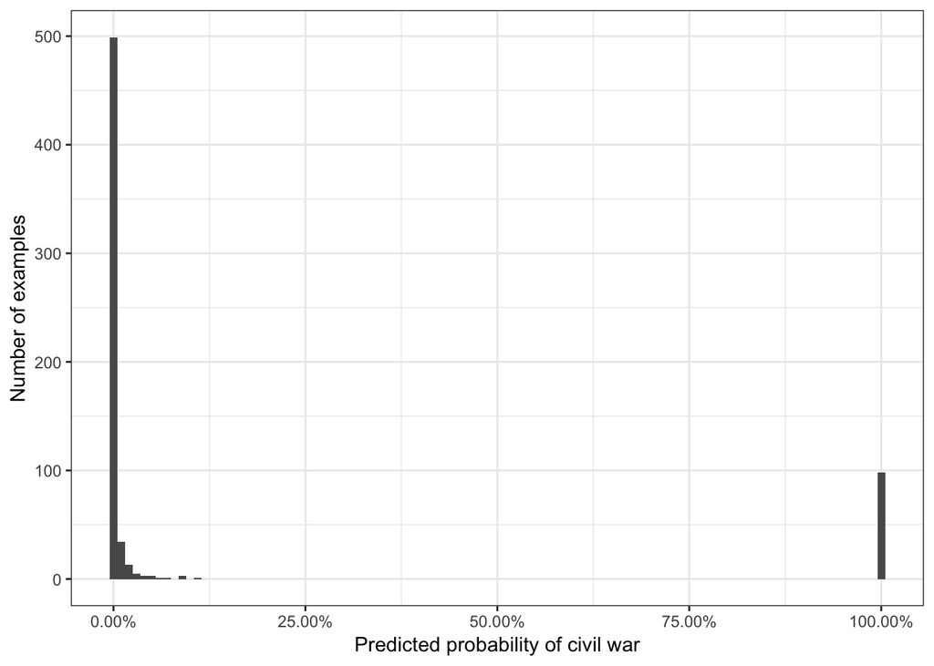

```r
# plot histogram of predicted probabilities
# note overconfident predictions
probs1 <- data.frame(predict(model1, test, type="raw"))
ggplot(probs1, aes(x = civil_war)) +
  geom_histogram(binwidth = 0.01) +
  scale_x_continuous(label = percent) +
  xlab('Predicted probability of civil war') +
  ylab('Number of examples')
```

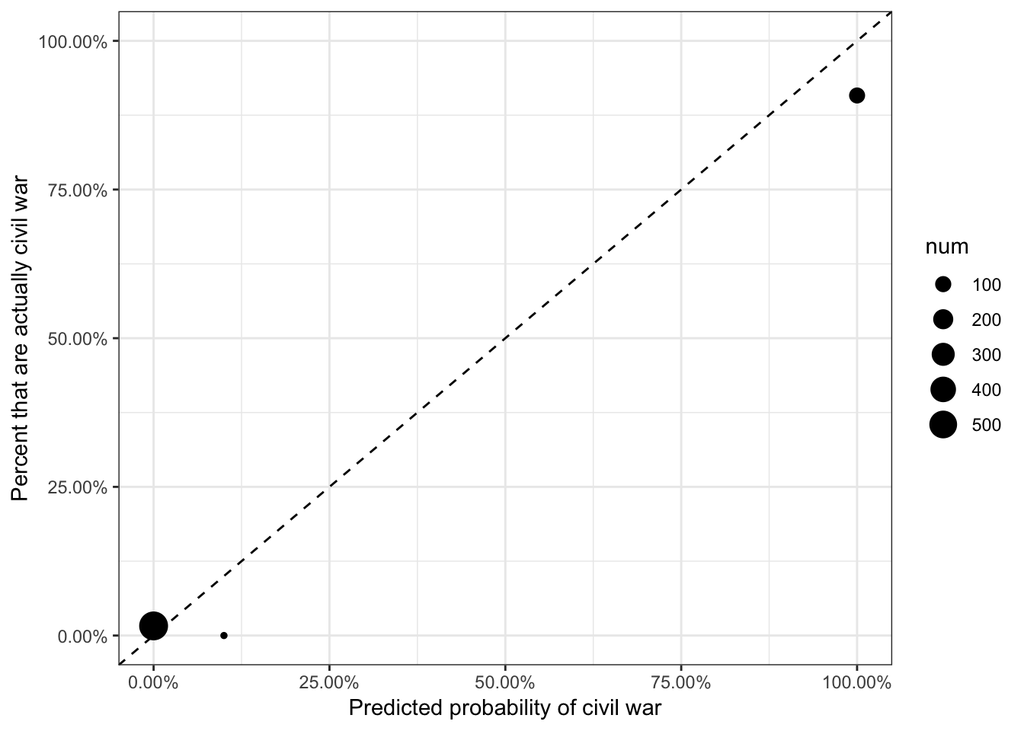

```r
data.frame(predicted=probs1[, "civil_war"], actual=yTest) %>%
  group_by(predicted=round(predicted*10)/10) %>%
  summarize(num=n(), actual=mean(actual == "civil_war")) %>%
  ggplot(data=., aes(x=predicted, y=actual, size=num)) +
  geom_point() +
  geom_abline(linetype=2) +
  scale_x_continuous(labels=percent, lim=c(0,1)) +
  scale_y_continuous(labels=percent, lim=c(0,1)) +
  xlab('Predicted probability of civil war') +
  ylab('Percent that are actually civil war')
```

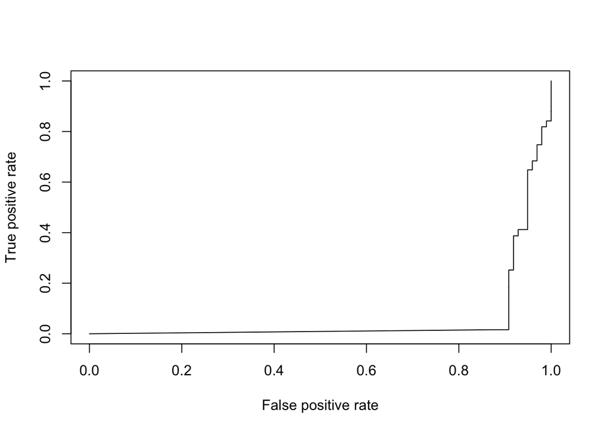

```r
# create a ROCR object
pred1 <- prediction(probs1[, "civil_war"], yTest)
# create a ROCR object
pred1 <- prediction(probs1[, "civil_war"], yTest)
# plot ROC curve
perf_nb1 <- performance(pred1, measure='tpr', x.measure='fpr')
plot(perf_nb1)
```

```r
performance(pred1, 'auc')
```

```
## An object of class "performance"
## Slot "x.name":
## [1] "None"
##
## Slot "y.name":
## [1] "Area under the ROC curve"
##
## Slot "alpha.name":
## [1] "none"
##
## Slot "x.values":
## list()
##
## Slot "y.values":
## [[1]]
## [1] 0.06068982
##
##
## Slot "alpha.values":
## list()
```

As we can see, the predicted probability of civil war outcome is quite low. We can only product about a 100 examples where we have a sure prediction. This is further confirmed by the second plot. Looking at the metrics we have calculated, we observe high accuracy, precision, and recall, and a very low false positive rate. High accuracy indicates that an outcome can be predicted as not a civil war and will actually end up not being a civil war. High precision also indicates that most of the predicted civil wars end up being civil wars. High recall also confirms more true positives than false negatives.

Further, our histogram is highly bimodal, which indicates Naive Bayes is overconfident in its low predicted probability. This is a consequence of the independence assumption.

### Comparing Naive Bayes and Logistic for war outcome

Logistic regression models are represented by one weight for each feature (previously listed), similar to Naive Bayes. The difference here is that the weights are learned together rather than independently.

So we compare Naive Bayes and the Logistic model for war outcome

```r
repdata <- repdata %>% group_by(war) %>% mutate(outcome = ifelse(war == 1 ,'1','0'))
repdata$outcome<- as.numeric(repdata$outcome)


set.seed(42)
ndx <- sample(nrow(repdata), floor(nrow(repdata) * 0.9))
train <- repdata[ndx,]
test <- repdata[-ndx,]
xTrain <- train[,-70]
yTrain <- train$outcome
xTest <- test[,-70]
yTest <- test$outcome

model <- glm(outcome ~ warl + gdpenl + lpopl1 + lmtnest
+ ncontig + Oil + nwstate + instab + polity2l + ethfrac + relfrac,  data = train, family = "binomial")

df <- data.frame(actual = yTest, log_odds = predict(model, xTest)) %>% mutate(pred = ifelse(log_odds > 0, 'war', 'no_war'))



# accuracy: fraction of correct classifications
df %>%
  summarize(acc = mean(pred == actual))
```

| acc |
| --- |
| NA |

```r
# precision: fraction of positive predictions that are actually true
df %>%
  filter(pred == 'war') %>%
  summarize(prec = mean(actual == 'war'))
```

| prec |
| --- |
| 0 |

```r
# recall: fraction of true examples that we predicted to be positive
# aka true positive rate, sensitivity
df %>%
  filter(actual == 'war') %>%
  summarize(recall = mean(pred == 'war'))
```

| recall |
| --- |
| NaN |

```r
# false positive rate: fraction of false examples that we predicted to be positive
df %>%
  filter(actual == 'no_war') %>%
  summarize(fpr = mean(pred == 'war'))
```

| fpr |
| --- |
| NaN |

```r
head(df)
```

|  | actual | log_odds | pred |
| --- | --- | --- | --- |
| 1 | 0 | -3.561415 | no_war |
| 2 | 0 | -4.279595 | no_war |
| 3 | 0 | -4.362449 | no_war |
| 4 | 0 | -4.596029 | no_war |
| 5 | 0 | -4.837728 | no_war |
| 6 | 0 | -4.046289 | no_war |

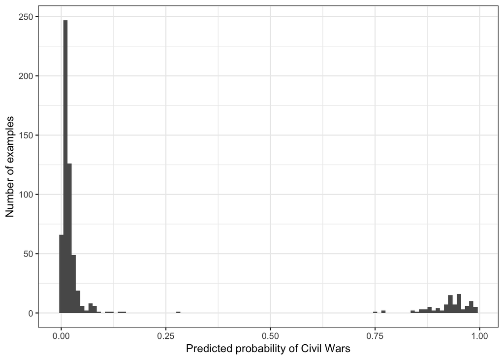

```r
# plot histogram of predicted probabilities
# note overconfident predictions

## plot histogram of predicted probabilities
test$probs <- predict(model, test, type="response")
ggplot(test, aes(x = probs)) +
  geom_histogram(binwidth = 0.01) +
  xlab('Predicted probability of Civil Wars') +
  ylab('Number of examples')
```

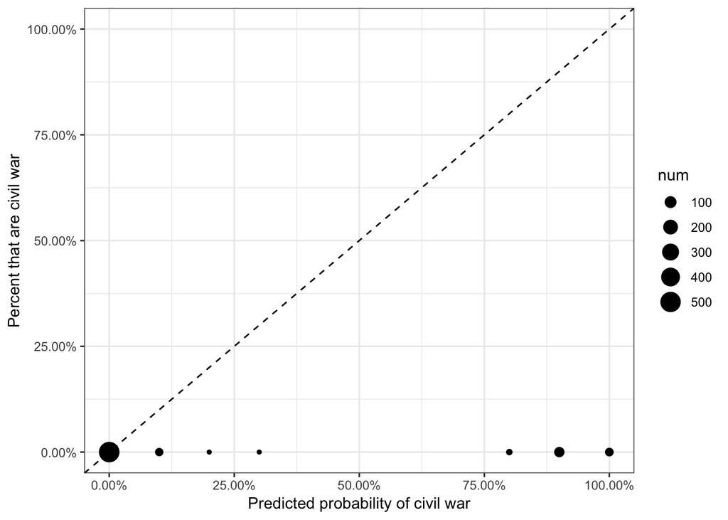

```r
#Plot calibration
data.frame(predicted=test$probs, actual=yTest) %>%
  group_by(predicted=round(predicted*10)/10) %>%
  summarize(num=n(), actual=mean(actual == "war")) %>%
  ggplot(data=., aes(x=predicted, y=actual, size=num)) +
  geom_point() +
  geom_abline(linetype=2) +
  scale_x_continuous(labels=percent, lim=c(0,1)) +
  scale_y_continuous(labels=percent, lim=c(0,1)) +
  xlab('Predicted probability of civil war') +
  ylab('Percent that are civil war')
```

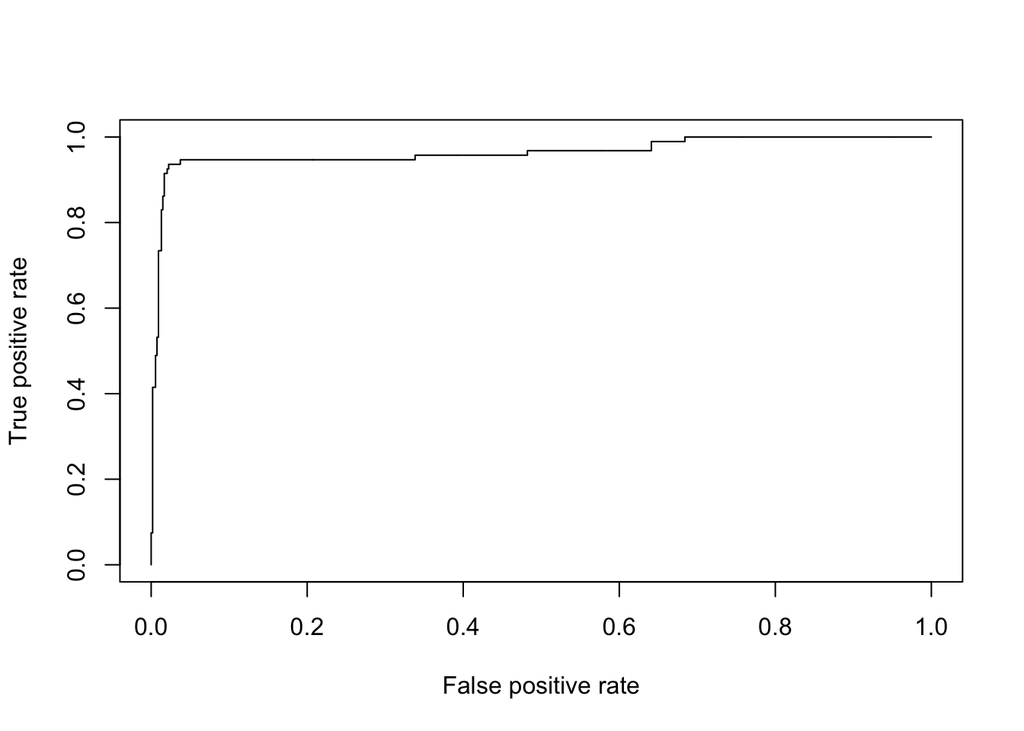

```r
#ROC Curve
pred <- prediction(test$probs, yTest)
perf_lr <- performance(pred, measure='tpr', x.measure='fpr')
plot(perf_lr)
```

```r
performance(pred, 'auc')
```

```
## An object of class "performance"
## Slot "x.name":
## [1] "None"
##
## Slot "y.name":
## [1] "Area under the ROC curve"
##
## Slot "alpha.name":
## [1] "none"
##
## Slot "x.values":
## list()
##
## Slot "y.values":
## [[1]]
## [1] 0.9636111
##
##
## Slot "alpha.values":
## list()
```

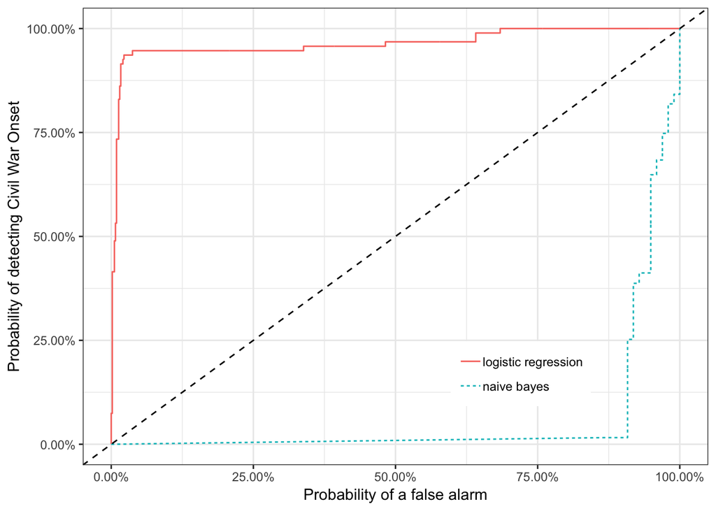

```r
#comparing Naive bayes and logistic regression for predictive war
roc_nb2 <- data.frame(fpr=unlist(perf_nb1@x.values), tpr=unlist(perf_nb1@y.values))
roc_nb2$method <- "naive bayes"

roc_lr2 <- data.frame(fpr=unlist(perf_lr@x.values), tpr=unlist(perf_lr@y.values))
roc_lr2$method <- "logistic regression"

rbind(roc_nb2, roc_lr2) %>%
  ggplot(data=., aes(x=fpr, y=tpr, linetype=method, color=method)) +
  geom_line() +
  geom_abline(linetype=2) +
  scale_x_continuous(labels=percent, lim=c(0,1)) +
  scale_y_continuous(labels=percent, lim=c(0,1)) +
  xlab('Probability of a false alarm') +
  ylab('Probability of detecting Civil War Onset') +
  theme(legend.position=c(0.7,0.2), legend.title=element_blank())
```

note: By plotting the actual distribution of predicted probabilities of civil war as an outcome, we have addressed the aforementioned overconfidence problem.

### Naive Bayes for Onset

Now we are using onset as the dependant variable using a Naive Bayes model.

```r
repdata <- repdata %>% group_by(onset) %>% mutate(onset_happens = ifelse(onset == 1 ,'onset','no_onset'))
repdata$onset_happens <- as.factor(repdata$onset_happens)

set.seed(42)
ndx <- sample(nrow(repdata), floor(nrow(repdata) * 0.9))
train <- repdata[ndx,]
test <- repdata[-ndx,]

xTrain <- train[,-71]
yTrain <- train$onset_happens

xTest <- test[,-71]
yTest <- test$onset_happens

model3 <- naiveBayes(onset_happens ~ warl + gdpenl + lpopl1 + lmtnest
+ ncontig + Oil + nwstate + instab + polity2l + ethfrac + relfrac,  data = train, family = "binomial")


df3 <- data.frame(actual = yTest, pred = predict(model3, test))
# accuracy: fraction of correct classifications
df3 %>%
  summarize(acc = mean(pred == actual))
```

| acc |
| --- |
| 0.9652042 |

```r
# precision: fraction of positive predictions that are actually true
df3 %>%
  filter(pred == 'onset') %>%
  summarize(prec = mean(actual == 'onset'))
```

| prec |
| --- |
| 0.1818182 |

```r
# recall: fraction of true examples that we predicted to be positive
# aka true positive rate, sensitivity
df3 %>%
  filter(actual == 'onset') %>%
  summarize(recall = mean(pred == 'onset'))
```

| recall |
| --- |
| 0.4444444 |

```r
# false positive rate: fraction of false examples that we predicted to be positive
df3 %>%
  filter(actual == 'no_onset') %>%
  summarize(fpr = mean(pred == 'onset'))
```

| fpr |
| --- |
| 0.02760736 |

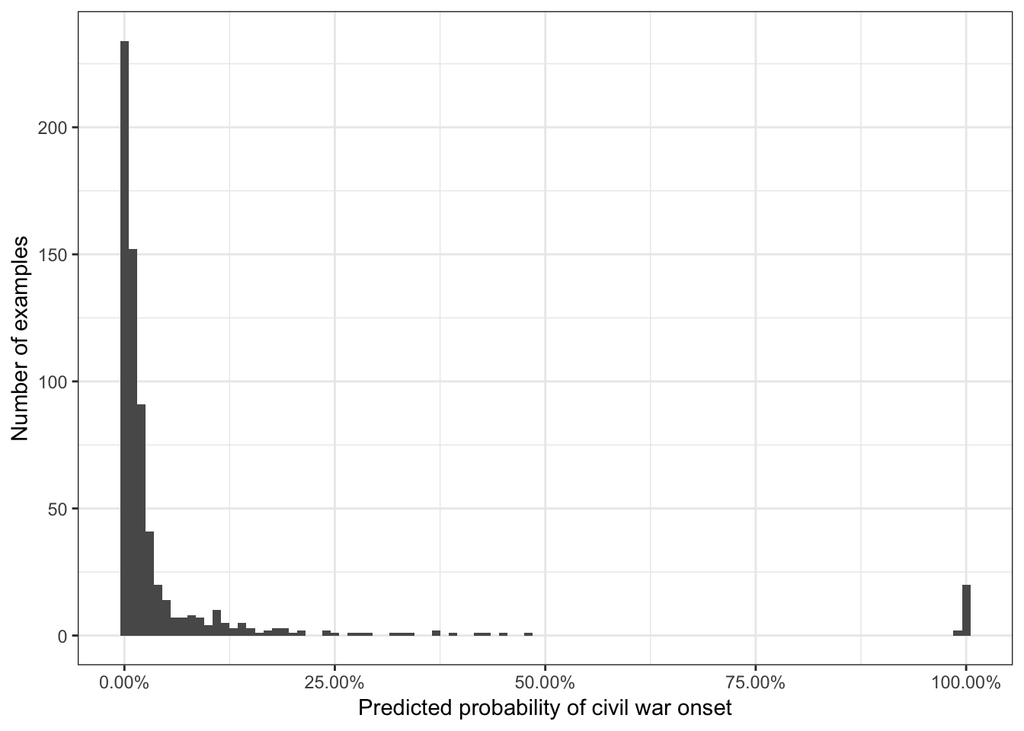

```r
# plot histogram of predicted probabilities
# note overconfident predictions
probs3 <- data.frame(predict(model3, test, type="raw"))
ggplot(probs3, aes(x = onset)) +
  geom_histogram(binwidth = 0.01) +
  scale_x_continuous(label = percent) +
  xlab('Predicted probability of civil war onset') +
  ylab('Number of examples')
```

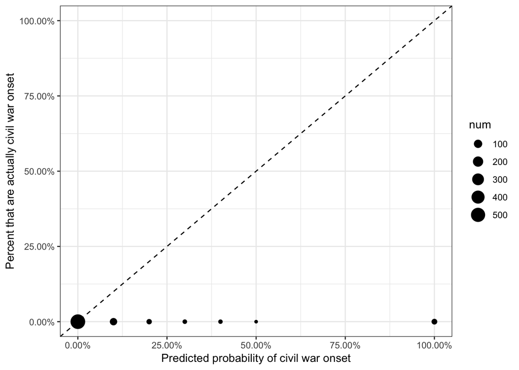

```r
data.frame(predicted=probs3[, "onset"], actual=yTest) %>%
  group_by(predicted=round(predicted*10)/10) %>%
  summarize(num=n(), actual=mean(actual == 1)) %>%
  ggplot(data=., aes(x=predicted, y=actual, size=num)) +
  geom_point() +
  geom_abline(linetype=2) +
  scale_x_continuous(labels=percent, lim=c(0,1)) +
  scale_y_continuous(labels=percent, lim=c(0,1)) +
  xlab('Predicted probability of civil war onset') +
  ylab('Percent that are actually civil war onset')
```

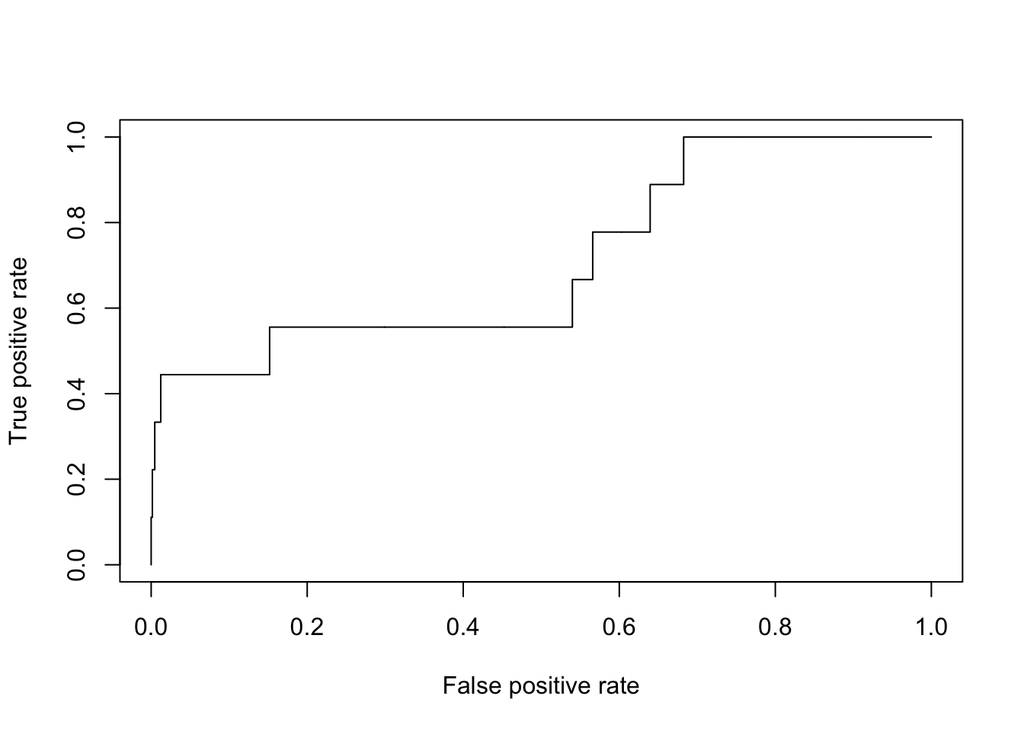

```r
# create a ROCR object
pred3 <- prediction(probs3[, "onset"], yTest)

# create a ROCR object
pred3 <- prediction(probs3[, "onset"], yTest)

# plot ROC curve
perf_nb3 <- performance(pred3, measure='tpr', x.measure='fpr')
plot(perf_nb3)
```

```r
performance(pred3, 'auc')
```

```
## An object of class "performance"
## Slot "x.name":
## [1] "None"
##
## Slot "y.name":
## [1] "Area under the ROC curve"
##
## Slot "alpha.name":
## [1] "none"
##
## Slot "x.values":
## list()
##
## Slot "y.values":
## [[1]]
## [1] 0.7113156
##
##
## Slot "alpha.values":
## list()
```

### Comparing logistic and Naive Bayes for onset

```r
repdata <- repdata %>% group_by(war) %>% mutate(onset_happens = ifelse(onset == 1 ,'1','0'))
repdata$onset_happens <- as.numeric(repdata$onset_happens)


set.seed(42)
ndx <- sample(nrow(repdata), floor(nrow(repdata) * 0.9))
train <- repdata[ndx,]
test <- repdata[-ndx,]

xTrain <- train[,-71]
yTrain <- train$onset_happens

xTest <- test[,-71]
yTest <- test$onset_happens


model <- glm(onset_happens ~ warl + gdpenl + lpopl1 + lmtnest
+ ncontig + Oil + nwstate + instab + polity2l + ethfrac + relfrac,  data = train, family = "binomial")

df5 <- data.frame(actual = yTest, log_odds = predict(model, xTest)) %>% mutate(pred = ifelse(log_odds > 0,'onset','no_onset'))





# accuracy: fraction of correct classifications
df5 %>%
  summarize(acc = mean(pred == actual))
```

| acc |
| --- |
| NA |

```r
# precision: fraction of positive predictions that are actually true
df5 %>%
  filter(pred == 'onset') %>%
  summarize(prec = mean(actual == 'onset'))
```

| prec |
| --- |
| NaN |

```r
# recall: fraction of true examples that we predicted to be positive
# aka true positive rate, sensitivity
df5 %>%
  filter(actual == 'onset') %>%
  summarize(recall = mean(pred == 'onset'))
```

| recall |
| --- |
| NaN |

```r
# false positive rate: fraction of false examples that we predicted to be positive
df5 %>%
  filter(actual == 'no_onset') %>%
  summarize(fpr = mean(pred == 'onset'))
```

| fpr |
| --- |
| NaN |

```r
head(df)
```

|  | actual | log_odds | pred |
| --- | --- | --- | --- |
| 1 | 0 | -3.561415 | no_war |
| 2 | 0 | -4.279595 | no_war |
| 3 | 0 | -4.362449 | no_war |
| 4 | 0 | -4.596029 | no_war |
| 5 | 0 | -4.837728 | no_war |
| 6 | 0 | -4.046289 | no_war |

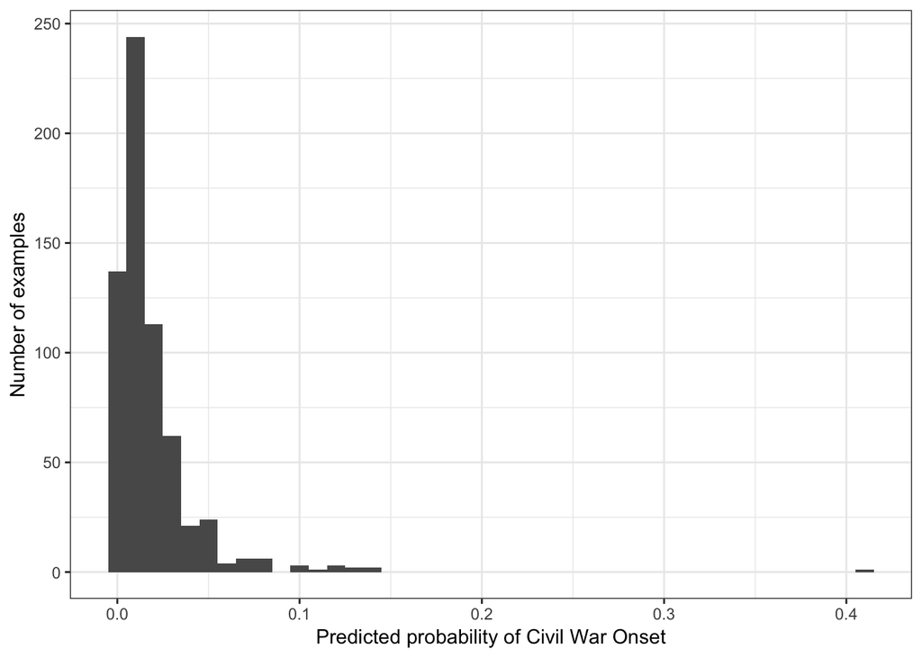

```r
# plot histogram of predicted probabilities
# note overconfident predictions

## plot histogram of predicted probabilities
test$probs <- predict(model, test, type="response")
ggplot(test, aes(x = probs)) +
  geom_histogram(binwidth = 0.01) +
  xlab('Predicted probability of Civil War Onset') +
  ylab('Number of examples')
```

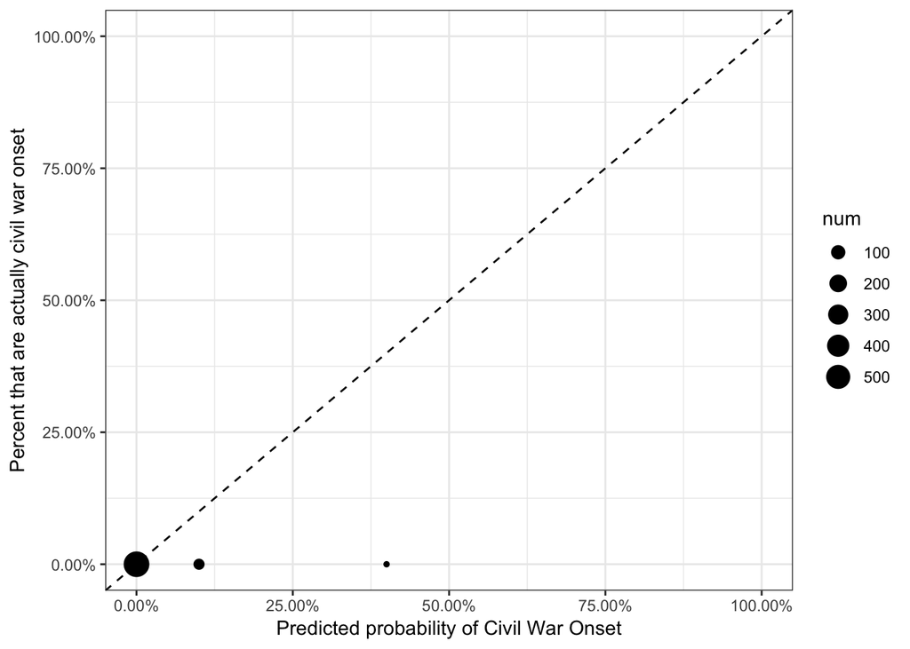

```r
#Plot calibration
data.frame(predicted=test$probs, actual=yTest) %>%
  group_by(predicted=round(predicted*10)/10) %>%
  summarize(num=n(), actual=mean(actual == "war")) %>%
  ggplot(data=., aes(x=predicted, y=actual, size=num)) +
  geom_point() +
  geom_abline(linetype=2) +
  scale_x_continuous(labels=percent, lim=c(0,1)) +
  scale_y_continuous(labels=percent, lim=c(0,1)) +
  xlab('Predicted probability of Civil War Onset') +
  ylab('Percent that are actually civil war onset')
```

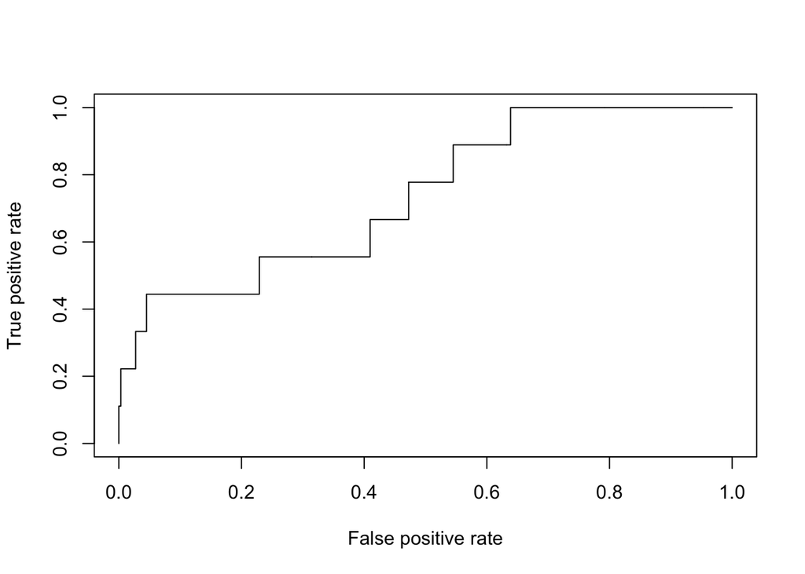

```r
#ROC Curve
pred <- prediction(test$probs, yTest)
perf_lr2 <- performance(pred, measure='tpr', x.measure='fpr')
plot(perf_lr2)
```

```r
performance(pred, 'auc')
```

```
## An object of class "performance"
## Slot "x.name":
## [1] "None"
##
## Slot "y.name":
## [1] "Area under the ROC curve"
##
## Slot "alpha.name":
## [1] "none"
##
## Slot "x.values":
## list()
##
## Slot "y.values":
## [[1]]
## [1] 0.7365591
##
##
## Slot "alpha.values":
## list()
```

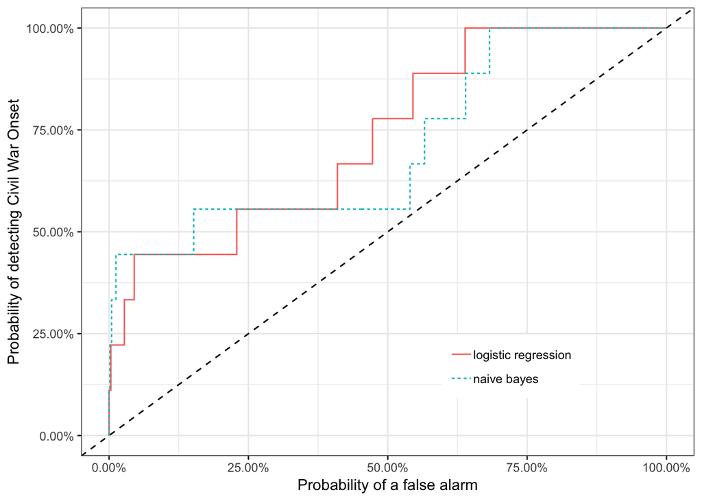

```r
#comparing Naive bayes and logistic regression for predictive onset
roc_nb <- data.frame(fpr=unlist(perf_nb3@x.values), tpr=unlist(perf_nb3@y.values))
roc_nb$method <- "naive bayes"

roc_lr <- data.frame(fpr=unlist(perf_lr2@x.values), tpr=unlist(perf_lr2@y.values))
roc_lr$method <- "logistic regression"

rbind(roc_nb, roc_lr) %>%
  ggplot(data=., aes(x=fpr, y=tpr, linetype=method, color=method)) +
  geom_line() +
  geom_abline(linetype=2) +
  scale_x_continuous(labels=percent, lim=c(0,1)) +
  scale_y_continuous(labels=percent, lim=c(0,1)) +
  xlab('Probability of a false alarm') +
  ylab('Probability of detecting Civil War Onset') +
  theme(legend.position=c(0.7,0.2), legend.title=element_blank())
```